# 2584023_Task1_Algo1

### 5. Algorithm: Linear Regression

Linear Regression models the target as a weighted sum of the features plus a constant: `y = b0 + b1*x1 + ... + b8*x8`, with weights chosen to minimise squared error - ordinary least squares (James et al., 2023). Used here as an interpretable baseline: each coefficient shows how much the predicted return moves per unit change in that feature, other features held fixed.

```python
from sklearn.linear_model import LinearRegression

linreg_model = LinearRegression()
linreg_model.fit(X_train, y_train)
linreg_pred = linreg_model.predict(X_test)

print('Intercept:', linreg_model.intercept_)
for name, coef in zip(feature_cols, linreg_model.coef_):
    print(f'  {name}: {coef:.5f}')

linreg_mae = mean_absolute_error(y_test, linreg_pred)
linreg_rmse = np.sqrt(mean_squared_error(y_test, linreg_pred))
linreg_r2 = r2_score(y_test, linreg_pred)
print(f'\nLinear Regression -> MAE: {linreg_mae:.5f} | RMSE: {linreg_rmse:.5f} | R2: {linreg_r2:.5f}')
```

```
Intercept: 0.02565657515265668
  return_1d: 0.00798
  volatility_10d: 0.01116
  dist_sma21: -0.00441
  dist_sma63: -0.00372
  dist_sma252: 0.00351
  rsi: -0.00049
  tsi: 0.00019
  tsi_signal: -0.00001

Linear Regression -> MAE: 0.01538 | RMSE: 0.02465 | R2: -0.00403
```

#### 5.1 Residual Diagnostics

A well-specified model shows residuals scattered randomly around zero, no funnel shape, and a roughly bell-shaped histogram. Strong patterns instead would mean the model is missing real structure.

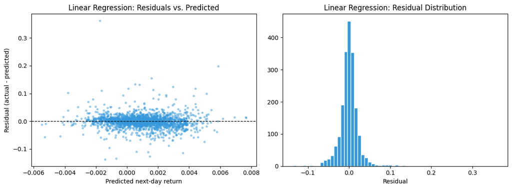

```
Residual std: 0.02465 (compare to target std: 0.02460)
```

```python
linreg_residuals = y_test - linreg_pred

fig, axes = plt.subplots(1, 2, figsize=(12, 4.5))
axes[0].scatter(linreg_pred, linreg_residuals, s=8, alpha=0.4, color='#3498db')
axes[0].axhline(0, color='black', linewidth=1, linestyle='--')
axes[0].set_title('Linear Regression: Residuals vs. Predicted')
axes[0].set_xlabel('Predicted next-day return')
axes[0].set_ylabel('Residual (actual - predicted)')

axes[1].hist(linreg_residuals, bins=60, color='#3498db', edgecolor='white')
axes[1].set_title('Linear Regression: Residual Distribution')
axes[1].set_xlabel('Residual')
plt.tight_layout()
plt.show()

print(f'Residual std: {linreg_residuals.std():.5f} (compare to target std: {y_test.std():.5f})')
```

### 6. Actual vs. Predicted

Plotting predictions against actual next-day returns, in time order, shows whether the model tracks real movement at all - not just whether its summary metrics look decent.

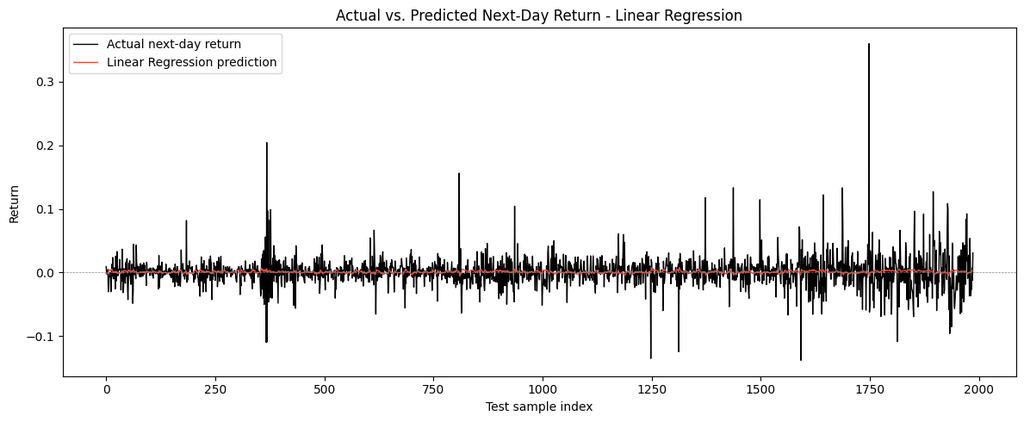

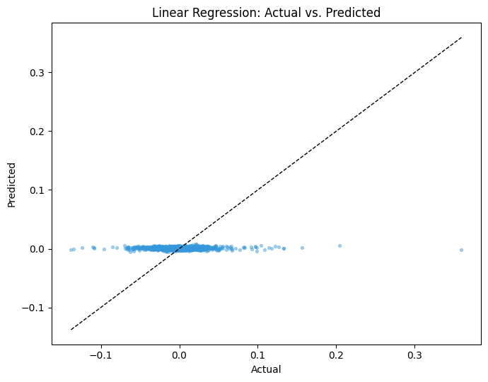

```python
fig, ax = plt.subplots(figsize=(12, 5))
ax.plot(y_test.values, label='Actual next-day return', color='black', linewidth=1)
ax.plot(linreg_pred, label='Linear Regression prediction', color='#e74c3c', linewidth=1)
ax.axhline(0, color='gray', linewidth=0.5, linestyle='--')
ax.set_title('Actual vs. Predicted Next-Day Return - Linear Regression')
ax.set_xlabel('Test sample index')
ax.set_ylabel('Return')
ax.legend()
plt.tight_layout()
plt.show()

fig, ax = plt.subplots(figsize=(7, 5.5))
ax.scatter(y_test, linreg_pred, s=8, alpha=0.4, color='#3498db')
ax.plot([y_test.min(), y_test.max()], [y_test.min(), y_test.max()], color='black', linestyle='--', linewidth=1)
ax.set_title('Linear Regression: Actual vs. Predicted')
ax.set_xlabel('Actual')
ax.set_ylabel('Predicted')
plt.tight_layout()
plt.show()
```

### 7. RSI Deep-Dive (Algorithm-Specific View)

Section 5's coefficient table already states how much weight the model puts on `rsi`. This plots the raw indicator directly, so that number can be read against what RSI actually looks like day to day.

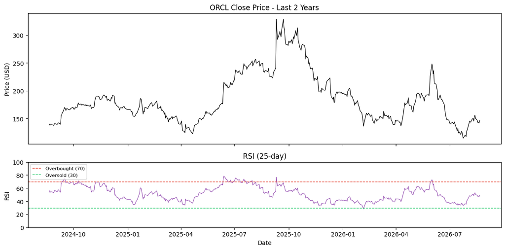

[output not shown]

```python
recent_window = orcl_1d_data.loc[orcl_1d_data.index >= orcl_1d_data.index.max() - pd.DateOffset(years=2)]

fig, axes = plt.subplots(2, 1, figsize=(12, 6), sharex=True, gridspec_kw={'height_ratios': [2, 1]})
axes[0].plot(recent_window.index, recent_window['close'], color='black', linewidth=0.9)
axes[0].set_title('ORCL Close Price - Last 2 Years')
axes[0].set_ylabel('Price (USD)')

axes[1].plot(recent_window.index, recent_window['RSI_25_Close'], color='#9b59b6', linewidth=0.9)
axes[1].axhline(70, color='#e74c3c', linestyle='--', linewidth=1, label='Overbought (70)')
axes[1].axhline(30, color='#2ecc71', linestyle='--', linewidth=1, label='Oversold (30)')
axes[1].set_ylim(0, 100)
axes[1].set_title('RSI (25-day)')
axes[1].set_ylabel('RSI')
axes[1].set_xlabel('Date')
axes[1].legend(loc='upper left', fontsize=8)
plt.tight_layout()
plt.show()

rsi_coef = linreg_model.coef_[feature_cols.index('rsi')]
print(f"Linear Regression's coefficient on rsi is only {rsi_coef:.5f}.")
print('RSI visibly swings between overbought and oversold zones several times over just the last')
print('2 years, yet Section 3 showed almost no linear correlation with next-day return - the small')
print('coefficient above is the model correctly learning that this swing carries little predictive weight.')
```

### 8. Cross-Validated Performance (More Robust Than a Single Split)

A single 80/20 split gives one noisy estimate - the model might look better or worse purely by chance. `TimeSeriesSplit` runs 5 chronological folds and averages the error, a more reliable comparison than one split.

```python
from sklearn.model_selection import TimeSeriesSplit

X_all = df[feature_cols]
y_all = df['target_next_return']

tscv = TimeSeriesSplit(n_splits=5)
cv_mae, cv_rmse = [], []

for train_idx, test_idx in tscv.split(X_all):
    X_tr, X_te = X_all.iloc[train_idx], X_all.iloc[test_idx]
    y_tr, y_te = y_all.iloc[train_idx], y_all.iloc[test_idx]
    fold_model = LinearRegression().fit(X_tr, y_tr)
    pred = fold_model.predict(X_te)
    cv_mae.append(mean_absolute_error(y_te, pred))
    cv_rmse.append(np.sqrt(mean_squared_error(y_te, pred)))

print('5-fold TimeSeriesSplit cross-validation for Linear Regression:')
print(f'Mean CV MAE:  {np.mean(cv_mae):.5f} (std {np.std(cv_mae):.5f})')
print(f'Mean CV RMSE: {np.mean(cv_rmse):.5f} (std {np.std(cv_rmse):.5f})')
```

```
5-fold TimeSeriesSplit cross-validation for Linear Regression:
Mean CV MAE:  0.01748 (std 0.00568)
Mean CV RMSE: 0.02547 (std 0.00797)
```